# Processing, modelling and vizualising hydrological data in R - director’s cut

Alexander Hurley a.g.hurley@pgr.bham.ac.uk https://aglhurley.rbind.io

May 05, 2018

# 1 Introduction

## 1.1 Purpose

This tutorial will showcase a set of R’s most prominent and widely-applicable set of packages, the `tidyverse`, and how it can be applied for hydrology work*flows*.

## 1.2 Aproach

Using (peak flow) data from the UK [National River Flow Archive](http://nrfa.ceh.ac.uk/) (NRFA), we will:

- clean, tidy and explore
- develop a scalable workflow for defining and applying statistical models (answering questions, cf. below)
- set-up (visual) model assessment framework to communicate results

**Question:**

- Q1: What impact does catchment area have on peak flows, and does it differ between countries?
- Q2: Which catchment properties affect peak flows and which set of characteristics make up the most representative models?

# 2 Why use the `tidyverse`?

## 2.1 We all want to..

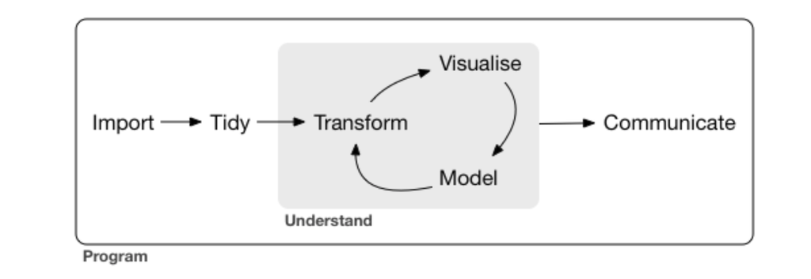

[Data analysis pipeline (taken from R4DS by H. Wickham)](http://r4ds.had.co.nz/introduction.html#what-you-will-learn)

## 2.2 Tidy philosphy

[The `tidyverse` philosophy postulates](http://tidyverse.tidyverse.org/articles/manifesto.html):

- Reuse existing data structures.
- Compose simple functions with the pipe.
- Embrace functional programming.
- Design for humans.

## 2.3 Concept: Piping

$$data~\rightarrow~f(data,~paramaters)~\rightarrow~output$$

> *data* $\rightarrow$ **f**(*data*, parameters) $\rightarrow$ outputs

```r
library(dplyr) # based on package magrittr, but loaded as dependency

1:10 %>% mean()
```

```
[1] 5.5
```

**More tangible example with iris data set**:

|  | Species | Sepal.Length | Sepal.Width | Petal.Length | Petal.Width |
| --- | --- | --- | --- | --- | --- |
| 1 | setosa | 5.1 | 3.5 | 1.4 | 0.2 |
| 2 | setosa | 4.9 | 3.0 | 1.4 | 0.2 |
| 3 | setosa | 4.7 | 3.2 | 1.3 | 0.2 |
| 4 | setosa | 4.6 | 3.1 | 1.5 | 0.2 |
| 5 | setosa | 5.0 | 3.6 | 1.4 | 0.2 |
| 6 | setosa | 5.4 | 3.9 | 1.7 | 0.4 |
| 7 | setosa | 4.6 | 3.4 | 1.4 | 0.3 |
| 8 | setosa | 5.0 | 3.4 | 1.5 | 0.2 |
| 9 | setosa | 4.4 | 2.9 | 1.4 | 0.2 |
| 10 | setosa | 4.9 | 3.1 | 1.5 | 0.1 |

[output cut: 10 more lines]

**Application:**

```r
library(dplyr)

iris %>%
  group_by(Species) %>%
  summarise_all(mean) %>%
  as.data.frame()
```

| Species | Sepal.Length | Sepal.Width | Petal.Length | Petal.Width |
| --- | --- | --- | --- | --- |
| setosa | 5.006 | 3.428 | 1.462 | 0.246 |
| versicolor | 5.936 | 2.770 | 4.260 | 1.326 |
| virginica | 6.588 | 2.974 | 5.552 | 2.026 |

## 2.4 Concept: Mapping

> *LIST* = (data1, data2, data3)  
> *LIST* $\rightarrow$ **map**(*LIST*, **f**, parameters) $\rightarrow$ **f**(*LIST[i]*, parameters) $\rightarrow$ outputs

The `purrr::map` family of functions (and others) allow for straight-forward functional programming and offer convenient functionalities. Try `map_int`, `map_dfr`, `modify_depth` and `possibly`

```r
library(purrr)


example_list <- list(first = data.frame(val = 1:5),
                     second = data.frame(val = 6:10),
                     third = data.frame(val = 11:15))

example_result <- example_list %>%
  map_dfr(~mutate(.x, val2 = val*2),
          .id = "identify_me")

example_result
```

| identify_me | val | val2 |
| --- | --- | --- |
| first | 1 | 2 |
| first | 2 | 4 |
| first | 3 | 6 |
| first | 4 | 8 |
| first | 5 | 10 |
| second | 6 | 12 |
| second | 7 | 14 |
| second | 8 | 16 |
| second | 9 | 18 |
| second | 10 | 20 |

[output cut: 5 more lines]

Useful (and powerful) approach for error-handling when using lists with unexpected data values with `possibly`:

```r
example_list <- list(first = data.frame(val = 1:5),
                     second = "not_a_number",
                     third = data.frame(val = 11:15))

# NOTRUN
# lapply(example_list, sum)

# this fails with:
# Error in FUN(X[[i]], ...) : invalid 'type' (character) of argument
```

Instead, we make a “possibly function” to catch the error.

```r
possible_sum <- possibly(sum, otherwise = "I am a failure, forgive me.")
lapply(example_list, possible_sum) # also works with map!
```

```
$first
[1] 15

$second
[1] "I am a failure, forgive me."

$third
[1] 65
```

## 2.5 Concept: Nesting

Data frames can store just about anything. Interestingly, one cell in a data frame can be made up of an entire list.

This makes for highly useful data management and analyses approaches:

Application:

```r
library(tidyr)


# regular data frame
iris
```

| Sepal.Length | Sepal.Width | Petal.Length | Petal.Width | Species |
| --- | --- | --- | --- | --- |
| 5.1 | 3.5 | 1.4 | 0.2 | setosa |
| 4.9 | 3.0 | 1.4 | 0.2 | setosa |
| 4.7 | 3.2 | 1.3 | 0.2 | setosa |
| 4.6 | 3.1 | 1.5 | 0.2 | setosa |
| 5.0 | 3.6 | 1.4 | 0.2 | setosa |
| 5.4 | 3.9 | 1.7 | 0.4 | setosa |
| 4.6 | 3.4 | 1.4 | 0.3 | setosa |
| 5.0 | 3.4 | 1.5 | 0.2 | setosa |
| 4.4 | 2.9 | 1.4 | 0.2 | setosa |
| 4.9 | 3.1 | 1.5 | 0.1 | setosa |

[output cut: 70 more lines]

```r
# nested data frame
nested_iris <- iris %>%
  nest(-Species)
nested_iris
```

| Species | data |
| --- | --- |
| setosa |  |
| versicolor |  |
| virginica |  |

```r
# add a model
nested_iris <-
  nested_iris %>%
  mutate(model_1 = map(data, ~lm(Sepal.Length ~ Sepal.Width, data = .x)))
nested_iris
```

| Species | data | model_1 |
| --- | --- | --- |
| setosa |  |  |
| versicolor |  |  |
| virginica |  |  |

Think: hierarchichal data structures, meta data, multiple models, etc.  
The nesting can be reversed by via `unnest(nested_iris)` to give a neat `data.frame`.

# 3 Getting the data

The next sections will:

- load necessary packages
- download and read-in data using the dedicated UK NRFA package `rnfra`, and an archive of [catchment descriptors](http://nrfa.ceh.ac.uk/feh-catchment-descriptors), available [here](http://nrfa.ceh.ac.uk/winfap-feh-files).
- tidy data and prepare for modelling

## 3.1 Set-up

Load necessary packages and custom plotting theme:

```r
# tidyverse packages - or just run: library(tidyverse)
library(fs) # file management
library(dplyr) # data manipulation
library(purrr) # functional programming
library(magrittr) # data manipulation / tidy code
library(ggplot2) # data viz
library(broom) # tidy stats results
library(forcats) # tidy factors
library(lubridate) # tidy dates
library(tibble) # data frames with extra functionalities
library(tidyr) # nesting and unnesting

# Environmental and spatial data/analyses
library(rnrfa) # flow archive
library(rgdal) # spatial data sets

# custom theme
source("../src/01_presentation.R")
```

## 3.2 Peak Flows and Meta Data

**Note:** *Data from the UK National River Flow Archive*.  
Please refer to http://nrfa.ceh.ac.uk/costs-terms-and-conditions prior to any re-use

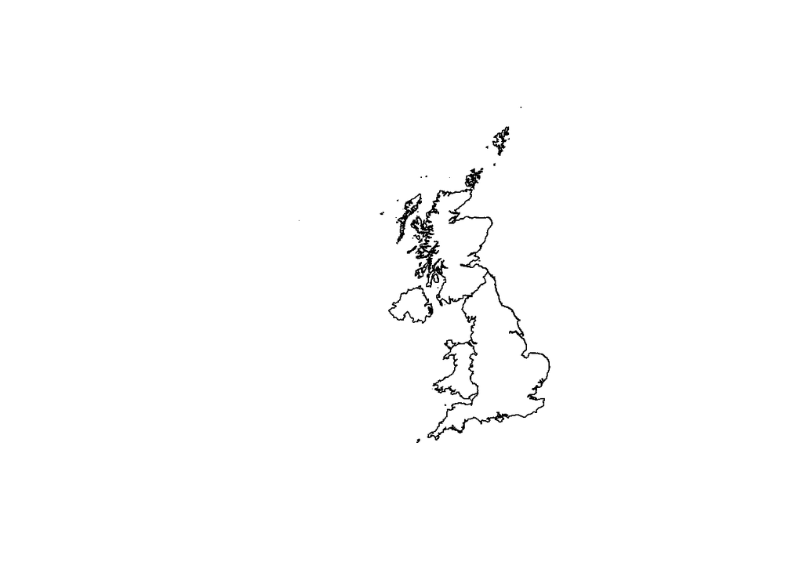

```r
# Catchment and Peak Flow Data ----------------------------

# Collect all station information using the rnrfa API

all_stations <- catalogue() # rnfra::stationSummary available for meta data

# remove some columns
all_stations <- all_stations %>%
  select(-`ma-station-id`,
         -`maximum-gauging-stage-date-time`,
         -`maximum-gauging-flow-date-time`,
         -benchmark2,
         -categories)



# columns where class change is necessary
char2num <- c("catchmentArea", "altitude", "maximum-gauging-flow", "lat", "lon")

all_stations[ ,char2num] %<>% map_dfc(as.numeric)





# Next lines for adding country label based on lat/lon location

# file info of shape files
shp_files <- fs::dir_info(path = "../dat/GBR_adm",
                          glob = "*.shp") #from http://www.diva-gis.org/datadown


# read in UK admin. shape files
gb_shp <- shp_files$path %>%
  map(readOGR)
# select country level admin. demarkation and plot
gb_countries <- gb_shp[[2]]
plot(gb_countries)
```

```r
# adjust projection
coordinates(all_stations) <- ~ lon + lat
proj4string(all_stations) <- proj4string(gb_countries)


# add labels
all_stations<- all_stations@data %>%
  mutate(country =  over(all_stations, gb_countries[ ,"NAME_1"])[[1]])


# make table
all_stations %>%
  as.data.frame()
```

| id | name | location | river | hydrometricArea | operator | haName | gridReference | stationType | catchmentArea | gdfStart | gdfEnd | farText | altitude | sensitivity | maximum-gauging-stage | maximum-gauging-flow | country |
| --- | --- | --- | --- | --- | --- | --- | --- | --- | --- | --- | --- | --- | --- | --- | --- | --- | --- |
| 1001 | Wick at Tarroul | Tarroul | Wick | 1 | Scottish Environment Protection Agency - North | Wick Group | ND262549 | Velocity-area | 161.9 | 1995 | 2016 | NA | 13.0 | 20 | NA | NA | Scotland |
| 2001 | Helmsdale at Kilphedir | Kilphedir | Helmsdale | 2 | Scottish Environment Protection Agency - North | Helmsdale Group | NC998181 | Velocity-area | 551.4 | 1975 | 2016 | R: Regulation from surface water and/or ground water. | 17.0 | 9.1 | 2.21 | 126.667 | Scotland |
| 2002 | Brora at Bruachrobie | Bruachrobie | Brora | 2 | Scottish Environment Protection Agency - North | Helmsdale Group | NC891039 | Velocity-area | 434.4 | 1993 | 2016 | NA | 9.0 | 11 | 1.78 | 93.977 | Scotland |
| 3001 | Shin at Lairg | Lairg | Shin | 3 | North of Scotland Hydro-Electric Board | Shin Group | NC581062 | Velocity-area | 494.6 | 1953 | 1957 | NA | 81.7 | 5.7 | NA | NA | Scotland |
| 3002 | Carron at Sgodachail | Sgodachail | Carron | 3 | Scottish Environment Protection Agency - North | Shin Group | NH491921 | Velocity-area | 241.1 | 1974 | 2016 | H: Regulation for hydro-electric power. | 70.7 | 14 | 2.65 | 182.088 | Scotland |
| 3003 | Oykel at Easter Turnaig | Easter Turnaig | Oykel | 3 | Scottish Environment Protection Agency - North | Shin Group | NC403001 | Velocity-area | 330.7 | 1977 | 2016 | N: Natural to within 10% at the 95 percentile flow. | 15.6 | 14 | 3.19 | 447.404 | Scotland |
| 3004 | Cassley at Rosehall | Rosehall | Cassley | 3 | Scottish Environment Protection Agency - North | Shin Group | NC471021 | Velocity-area | 187.5 | 1979 | 2016 | H: Regulation for hydro-electric power. | 3.3 | 6 | NA | NA | Scotland |
| 3005 | Shin at Inveran | Inveran | Shin | 3 | Scottish Environment Protection Agency - North | Shin Group | NH574974 | Velocity-area | 575.0 | 1981 | 2011 | H: Regulation for hydro-electric power. | 4.3 | 7 | NA | NA | Scotland |
| 3006 | Loch Ailsh at Loch Ailsh | Loch Ailsh | Loch Ailsh | 3 | Scottish Environment Protection Agency - North | Shin Group | NC315101 | Velocity-area | 44.3 | 2006 | 2016 | NA | 154.3 | NA | NA | NA | Scotland |
| 4001 | Conon at Moy Bridge | Moy Bridge | Conon | 4 | Scottish Environment Protection Agency - North | Conon Group | NH481546 | Velocity-area | 961.8 | 1947 | 2016 | H: Regulation for hydro-electric power. | 10.0 | 6 | NA | NA | Scotland |

[output cut: 10 more lines]

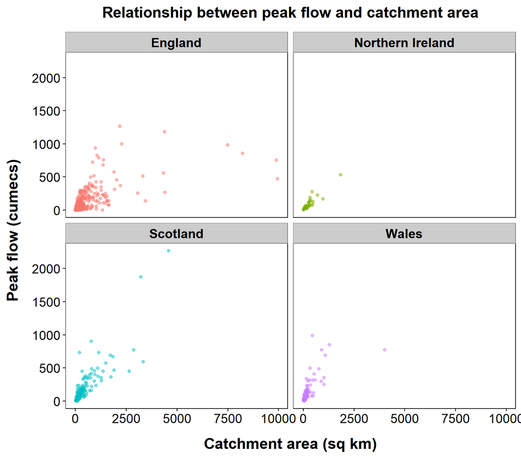

```r
# exploratory plot
exp_catchment_area.plot <- all_stations %>%
  ggplot(aes(x = catchmentArea,
             y = `maximum-gauging-flow`,
             col = country,
             text = paste("Name:",name))) +

  geom_point(alpha = 0.5, show.legend = F) +

  theme_presi() +
  ggtitle("Relationship between peak flow and catchment area") +
  labs(y = "Peak flow (cumecs)", x = "Catchment area (sq km)") +

  facet_wrap(~country)

exp_catchment_area.plot
```

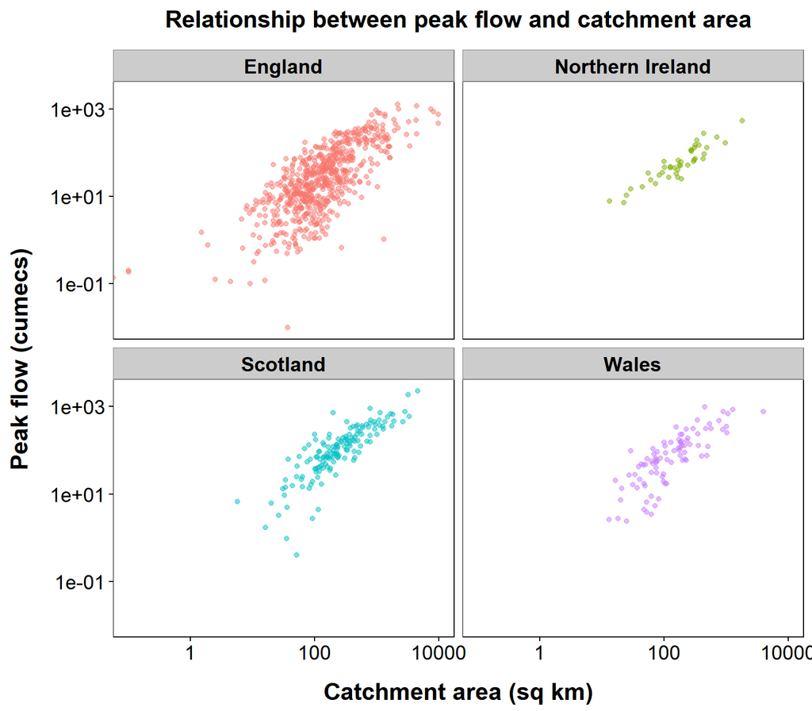

```r
# Better at log scale?

log_exp_catchment_area.plot <- exp_catchment_area.plot +
  scale_x_log10() +
  scale_y_log10()

log_exp_catchment_area.plot
```

## 3.3 FEH Catchment Descriptors

The [FEH catchment descriptor data](http://nrfa.ceh.ac.uk/winfap-feh-files) is stored in individual *.cd3 files per catchment (`id` as file name and unique identifier in file). They contain some preceding and trailing meta data in a non-rectangular format. We extract and skip lines as needed in a custom function to achieve a programmatic read-in.

**Note:** *Data from the UK National River Flow Archive*.  
Please refer to http://nrfa.ceh.ac.uk/costs-terms-and-conditions prior to any re-use

```r
# uses custom function read_cd3, source code available in raw document.


cd3_data <- fs::dir_info("../dat/CEH_FEH/",
                         glob = "*.CD3",
                         recursive = T)$path %>%
  map_dfr(read_cd3)

cd3_data %>% head(20) %>% as.data.frame()
```

| ALTBAR | ASPBAR | ASPVAR | BFIHOST | CATCHMENT | CENTROID NGR | DPLBAR | DPSBAR | DTM AREA | FARL | FPEXT | IHDTM NGR | LDP | LOCATION | NAME | NOMINAL AREA | NOMINAL NGR | POOLING | Pooling Suitability | PROPWET | QMED | Qmed Suitability | RMED-1D | RMED-1H | RMED-2D | SAAR | SAAR4170 | SPRHOST | STATION | URBCONC1990 | … |
| --- | --- | --- | --- | --- | --- | --- | --- | --- | --- | --- | --- | --- | --- | --- | --- | --- | --- | --- | --- | --- | --- | --- | --- | --- | --- | --- | --- | --- | --- | --- |
| 151 | 123 | 0.22 | 0.511 | Mostly low-lying catchment. Bedrock predominantly Carboniferous rocks; predominately overlain by superficial deposits. Land use lowland arable farming | GB | 26.89 | 62.9 | 416.53 | 0.824 | 0.1008 | GB | 48.68 | Leven | Leven | 416.53 | 3368 | NO | Rating review required for all periods (recommendation made in 2003 at time of HIFLOWS data compilation) | 0.45 | NO | Rating review required for all periods (recommendation made in 2003 at time of HIFLOWS data compilation) | 35.5 | 8.8 | 47.1 | 947 | 951 | 34.63 | Velocity area station in Scotland. Flows affected by lochs within the catchment. GENERAL: Velocity area station on a straight reach with artificially heightened and steeped banks. STATION HYDROMETRY: … | 0.754 | … |
| 212 | 252 | 0.24 | 0.346 | Predominantly upland area - mostly heath | Ireland | 18.60 | 64.6 | 126.46 | 0.992 | 0.0712 | Ireland | 33.00 | Curry's Bridge | Kellswater | 126.46 | 3105 | NO | High flows not contained however growth curve does look representative. | 0.54 | NO | Get out of bank before QMED and the percentage of unmeasured floodplain flow is significantly larger than 20% | 41.5 | 10.6 | 54.9 | 1188 | 1231 | 44.57 | Velocity area station with cableway and natural control. GENERAL: Velocity area station 1.5km d/s of confluence with the R Main. STATION HYDROMETRY: Cableway present. Bridge downstream does not backup… | -0.002 | … |
| 104 | 296 | 0.04 | 0.450 | Heavily overlain with till and extensive sand and gravel deposits in lower reaches of the river. Mainly arable | Ireland | 33.14 | 59.6 | 448.72 | 0.981 | 0.0989 | Ireland | 69.99 | Dunmurry | Lagan | 448.72 | 3298 | NO | Rating deviates from check gaugings at high flows by 30% and more. The station is now closed but was contained by wing walls of Motorway bridge rating has received no further attention. | 0.52 | NO | No - Flows are significantly less than Newforge | 35.8 | 10.4 | 46.7 | 912 | 945 | 39.02 | Velocity area station with cableway. GENERAL: Opened 1970 immediately upstream of motorway bridge on left bank | -2.000 | … |
| 131 | 310 | 0.10 | 0.423 | Upland heath rising to over 500m. Remainder is agricultural grassland except for the town of Dromore. Geology - entirely Silurian overlain with till. | Ireland | 19.69 | 75.5 | 178.55 | 0.992 | 0.0808 | Ireland | 36.26 | Banoge | Lagan | 178.55 | 3123 | NO | No - Not suitable for use in pooling groups. River gets out of bank at high flows on both sides of the river | 0.53 | NO | No - Not suitable for QMED estimation as the maximum gauged flow is only 0.28 times the flow at QMED. | 37.5 | 10.5 | 48.7 | 927 | 986 | 41.03 | Velocity area station | -2.000 | … |
| 386 | 17 | 0.23 | 0.298 | Uplands covered with peat | GB | 12.10 | 106.0 | 88.25 | 0.997 | 0.0268 | GB | 23.04 | Wide Eals | East Allen | 88.25 | 3802 | NO | No evidence to support high flow rating. | 0.59 | NO | Not gauged to within 30% of QMED. | 40.2 | 10.3 | 53.6 | 1050 | 1152 | 47.58 | Velocity area station with no known artificial influences. Station closed 1981. GENERAL: Velocity area station with boulder and gravel control which is mobile at high flows. Discontinued 1981. STATION… | -9999.000 | … |
| 190 | 99 | 0.14 | 0.476 | Catchment drains a large tract of the East side of the Pennines | GB | 71.44 | 92.1 | 1935.97 | 0.939 | 0.0717 | GB | 120.39 | Beal Weir | Aire | 1935.97 | 4530 | NO | Although gauged above QMED | 0.38 | NO | Although gauged above QMED | 37.9 | 10.7 | 50.6 | 981 | 976 | 33.23 | Broad-crested masonry weir. The heavily reservoired catchment drains a large part of the East Pennines. GENERAL: Broad-crested masonry weir (33.5m wide) with an additional 9.1m of sluices on the right… | 0.771 | … |
| 214 | 88 | 0.16 | 0.527 | Mixed permeability geology of Carboniferous Sediments; Millstone Grit in the upper catchment | GB | 44.30 | 108.5 | 905.89 | 0.924 | 0.0489 | GB | 75.81 | Newlands | Calder | 905.89 | 4365 | NO | No gaugings beyond QMED to confirm high flows and record length at Newlands not sufficiently long enough. | 0.40 | NO | For the duration of Newlands (not Kirkthorpe) record only. | 39.9 | 10.9 | 53.9 | 1043 | 1046 | 29.97 | Velocity area station. Replaced Kirkthorpe Weir in 1968. Station closed in 1977 and replaced by 27079 (Methley) in 1988. GENERAL: Velocity area station | 0.733 | … |
| 126 | 163 | 0.14 | 0.604 | Large catchment with mixed geology. Predominantly rural | GB | 58.80 | 76.1 | 1639.27 | 0.994 | 0.1408 | GB | 104.56 | Stamford Bridge | Derwent | 1639.27 | 4711 | NO | No gaugings are documented so suitability cannot be assessed. | 0.34 | NO | No gaugings are documented so suitability cannot be assessed. | 32.2 | 10.6 | 42.2 | 763 | 782 | 28.44 | Velocity area station | 0.541 | … |
| 96 | 129 | 0.24 | 0.466 | The natural catchment drains part of the North York Moors. Contributing area varies by +/- 88.8 sq.km because of the artificial connection to the headwaters of the Derwent. Geology of natural catchmen… | GB | 6.64 | 79.4 | 32.91 | 0.999 | 0.0458 | GB | 13.44 | Scarborough | Sea Cut | 32.91 | 5027 | NO | As QMED. Flow measurement is thought to be fairly reliable but not recommended for pooling without careful consideration of the extended catchment area and characteristics. | 0.33 | NO | Flood flows artificially diverted into the catchment from the Upper Derwent | 34.4 | 10.7 | 44.3 | 753 | 767 | 33.13 | Compound broad-crested weir in a diversion channel passing flood waters from the upper Derwent. This means the contributing area varies at high flows. GENERAL: Compound broad-crested weir 21m wide wit… | 0.661 | … |
| 132 | 79 | 0.11 | 0.471 | Alluvial and clay drift underlain by Keuper Marl. Heavily built up - Birmingham and Black Country. | GB | 29.02 | 30.6 | 794.74 | 0.946 | 0.1176 | GB | 53.21 | Lea Marston | Tame | 794.74 | 4206 | NO | Massive scatter in the gaugings at all levels | 0.30 | NO | Massive scatter in the gaugings at all levels | 32.9 | 10.8 | 40.8 | 716 | 722 | 36.22 | Station replaced by Lea Marston Lakes (28080) in 1982. GENERAL: Station replaced by Lea Marston Lakes (28080) in 1982. STATION HYDROMETRY: Gauging carried out from bridge and includes all flows. Howev… | 0.862 | … |

[output cut: 10 more lines]

```r
cd3_data <- cd3_data %>%

  # choose only non-text values to apply "is.numeric"
  mutate_if(.predicate = function(x){
    any(!stringr::str_detect(x, ".*[a-zA-Z]")==T & !is.na(x))},
    .funs = as.numeric) %>%

  # select only numeric values
  select_if(.predicate = is.numeric) %>%

  # replace -9999 with NA
  mutate_all(funs(replace(., .< -9000, NA)))

cd3_data %>% as.data.frame()
```

| ALTBAR | ASPBAR | ASPVAR | BFIHOST | DPLBAR | DPSBAR | DTM AREA | FARL | FPEXT | LDP | NOMINAL AREA | NOMINAL NGR | PROPWET | RMED-1D | RMED-1H | RMED-2D | SAAR | SAAR4170 | SPRHOST | URBCONC1990 | URBCONC2000 | URBEXT1990 | URBEXT2000 | URBLOC1990 | URBLOC2000 | id |
| --- | --- | --- | --- | --- | --- | --- | --- | --- | --- | --- | --- | --- | --- | --- | --- | --- | --- | --- | --- | --- | --- | --- | --- | --- | --- |
| 151 | 123 | 0.22 | 0.511 | 26.89 | 62.9 | 416.53 | 0.824 | 0.1008 | 48.68 | 416.53 | 3368 | 0.45 | 35.5 | 8.8 | 47.1 | 947 | 951 | 34.63 | 0.754 | 0.830 | 0.0173 | 0.0360 | 0.740 | 0.703 | 17002 |
| 212 | 252 | 0.24 | 0.346 | 18.60 | 64.6 | 126.46 | 0.992 | 0.0712 | 33.00 | 126.46 | 3105 | 0.54 | 41.5 | 10.6 | 54.9 | 1188 | 1231 | 44.57 | -0.002 | NA | 0.0044 | 0.0019 | NA | NA | 203021 |
| 104 | 296 | 0.04 | 0.450 | 33.14 | 59.6 | 448.72 | 0.981 | 0.0989 | 69.99 | 448.72 | 3298 | 0.52 | 35.8 | 10.4 | 46.7 | 912 | 945 | 39.02 | -2.000 | 0.857 | 0.0373 | 0.0309 | 0.413 | 0.408 | 205003 |
| 131 | 310 | 0.10 | 0.423 | 19.69 | 75.5 | 178.55 | 0.992 | 0.0808 | 36.26 | 178.55 | 3123 | 0.53 | 37.5 | 10.5 | 48.7 | 927 | 986 | 41.03 | -2.000 | 0.776 | 0.0223 | 0.0065 | 0.747 | 0.646 | 205010 |
| 386 | 17 | 0.23 | 0.298 | 12.10 | 106.0 | 88.25 | 0.997 | 0.0268 | 23.04 | 88.25 | 3802 | 0.59 | 40.2 | 10.3 | 53.6 | 1050 | 1152 | 47.58 | NA | NA | 0.0017 | 0.0017 | NA | NA | 23012 |
| 190 | 99 | 0.14 | 0.476 | 71.44 | 92.1 | 1935.97 | 0.939 | 0.0717 | 120.39 | 1935.97 | 4530 | 0.38 | 37.9 | 10.7 | 50.6 | 981 | 976 | 33.23 | 0.771 | 0.853 | 0.1032 | 0.1313 | 0.745 | 0.768 | 27003 |
| 214 | 88 | 0.16 | 0.527 | 44.30 | 108.5 | 905.89 | 0.924 | 0.0489 | 75.81 | 905.89 | 4365 | 0.40 | 39.9 | 10.9 | 53.9 | 1043 | 1046 | 29.97 | 0.733 | 0.815 | 0.0855 | 0.1046 | 0.718 | 0.749 | 27004 |
| 126 | 163 | 0.14 | 0.604 | 58.80 | 76.1 | 1639.27 | 0.994 | 0.1408 | 104.56 | 1639.27 | 4711 | 0.34 | 32.2 | 10.6 | 42.2 | 763 | 782 | 28.44 | 0.541 | 0.721 | 0.0071 | 0.0080 | 0.874 | 0.861 | 27015 |
| 96 | 129 | 0.24 | 0.466 | 6.64 | 79.4 | 32.91 | 0.999 | 0.0458 | 13.44 | 32.91 | 5027 | 0.33 | 34.4 | 10.7 | 44.3 | 753 | 767 | 33.13 | 0.661 | 0.825 | 0.0379 | 0.0530 | 0.505 | 0.476 | 27033 |
| 132 | 79 | 0.11 | 0.471 | 29.02 | 30.6 | 794.74 | 0.946 | 0.1176 | 53.21 | 794.74 | 4206 | 0.30 | 32.9 | 10.8 | 40.8 | 716 | 722 | 36.22 | 0.862 | 0.944 | 0.2707 | 0.3827 | 1.082 | 1.116 | 28004 |

[output cut: 10 more lines]

## 3.4 Finalized data set

The final data set will contain

- peak flow
- select meta data
- [FEH catchment descriptor data](http://nrfa.ceh.ac.uk/winfap-feh-files)

```r
# some wrangling
all_stations <- all_stations %>%
  select(id, country, catchmentArea,  peak_flow_cumecs = `maximum-gauging-flow`)



# join by id
all_stations <- all_stations %>%
  left_join(cd3_data %>%
              mutate(id = as.character(id)),
            by = 'id')


all_stations %>% head(20) %>% as.data.frame()
```

|  | id | country | catchmentArea | peak_flow_cumecs | ALTBAR | ASPBAR | ASPVAR | BFIHOST | DPLBAR | DPSBAR | DTM AREA | FARL | FPEXT | LDP | NOMINAL AREA | NOMINAL NGR | PROPWET | RMED-1D | RMED-1H | RMED-2D | SAAR | SAAR4170 | SPRHOST | URBCONC1990 | URBCONC2000 | URBEXT1990 | URBEXT2000 | URBLOC1990 | URBLOC2000 |
| --- | --- | --- | --- | --- | --- | --- | --- | --- | --- | --- | --- | --- | --- | --- | --- | --- | --- | --- | --- | --- | --- | --- | --- | --- | --- | --- | --- | --- | --- |
| 1 | 1001 | Scotland | 161.9 | NA | NA | NA | NA | NA | NA | NA | NA | NA | NA | NA | NA | NA | NA | NA | NA | NA | NA | NA | NA | NA | NA | NA | NA | NA | NA |
| 2 | 2001 | Scotland | 551.4 | 126.667 | 213 | 201 | 0.04 | 0.324 | 30.33 | 97.0 | 553.24 | 0.858 | 0.0555 | 56.78 | 553.24 | 2998 | 0.65 | 33.0 | 8.3 | 43.7 | 1117 | 1102 | 52.88 | NA | NA | 0e+00 | 0e+00 | NA | NA |
| 3 | 2002 | Scotland | 434.4 | 93.977 | 259 | 178 | 0.15 | 0.351 | 28.71 | 97.3 | 423.48 | 0.845 | 0.0553 | 52.37 | 423.48 | 2891 | 0.59 | 36.4 | 8.8 | 48.9 | 1217 | 1190 | 54.16 | NA | NA | 0e+00 | 2e-04 | NA | NA |
| 4 | 3001 | Scotland | 494.6 | NA | NA | NA | NA | NA | NA | NA | NA | NA | NA | NA | NA | NA | NA | NA | NA | NA | NA | NA | NA | NA | NA | NA | NA | NA | NA |
| 5 | 3002 | Scotland | 241.1 | 182.088 | 439 | 44 | 0.06 | 0.436 | 15.94 | 218.2 | 237.14 | 0.974 | 0.0377 | 31.93 | 237.14 | 2491 | 0.81 | 43.7 | 9.2 | 65.4 | 1784 | 2024 | 49.93 | NA | NA | 0e+00 | 0e+00 | NA | NA |
| 6 | 3003 | Scotland | 330.7 | 447.404 | 297 | 61 | 0.07 | 0.359 | 16.79 | 148.2 | 331.67 | 0.915 | 0.0488 | 31.20 | 331.67 | 2403 | 0.81 | 45.4 | 9.4 | 65.2 | 1896 | 1962 | 53.57 | NA | NA | 0e+00 | 0e+00 | NA | NA |
| 7 | 3004 | Scotland | 187.5 | NA | NA | NA | NA | NA | NA | NA | NA | NA | NA | NA | NA | NA | NA | NA | NA | NA | NA | NA | NA | NA | NA | NA | NA | NA | NA |
| 8 | 3005 | Scotland | 575.0 | NA | NA | NA | NA | NA | NA | NA | NA | NA | NA | NA | NA | NA | NA | NA | NA | NA | NA | NA | NA | NA | NA | NA | NA | NA | NA |
| 9 | 3006 | Scotland | 44.3 | NA | NA | NA | NA | NA | NA | NA | NA | NA | NA | NA | NA | NA | NA | NA | NA | NA | NA | NA | NA | NA | NA | NA | NA | NA | NA |
| 10 | 4001 | Scotland | 961.8 | NA | NA | NA | NA | NA | NA | NA | NA | NA | NA | NA | NA | NA | NA | NA | NA | NA | NA | NA | NA | NA | NA | NA | NA | NA | NA |

[output cut: 10 more lines]

```r
# select variables for modelling (i.e. after checking for multi-colinearity)
all_stations <- all_stations %>%
  select(id, country, catchmentArea, peak_flow_cumecs,
         DPSBAR, FARL, FPEXT, SPRHOST,PROPWET)

all_stations <- all_stations[complete.cases(all_stations), ]

# number of observations per country
all_stations %>% dplyr::count(country) %>% as.data.frame()
```

| country | n |
| --- | --- |
| England | 618 |
| Northern Ireland | 42 |
| Scotland | 148 |
| Wales | 91 |

# 4 Statistical Modelling Workflow

This sections outlines the definition and application of statistical models to answer our questions (recall: difference between countries; what controls peak flow).

In a first step we will apply a simple linear model, and then build upon `tidyverse`’s data-handling capabilities to expand our analyses. The chosen modelling framework is mainly for illustrative purposes and can easily be exchanged with GLM, LME, NLS, GAM, etc.

## 4.1 Q1: Does size matter?

**Recall:**

Q: What impact does catchment area have on peak flows, and does it differ between countries?

### 4.1.1 Analyses:

```r
library(modelr)

# transform peak flow and catchment area with log10 in new object
p_data <- all_stations %>%
  mutate(peak_flow_cumecs_log = log10(peak_flow_cumecs),
         ca_log = log10(catchmentArea)) %>%
  filter(is.finite(peak_flow_cumecs_log),
         is.finite(ca_log))

p_data
```

| id | country | catchmentArea | peak_flow_cumecs | DPSBAR | FARL | FPEXT | SPRHOST | PROPWET | peak_flow_cumecs_log | ca_log |
| --- | --- | --- | --- | --- | --- | --- | --- | --- | --- | --- |
| 2001 | Scotland | 551.4 | 126.667 | 97.0 | 0.858 | 0.0555 | 52.88 | 0.65 | 2.1026635 | 2.741467 |
| 2002 | Scotland | 434.4 | 93.977 | 97.3 | 0.845 | 0.0553 | 54.16 | 0.59 | 1.9730216 | 2.637890 |
| 3002 | Scotland | 241.1 | 182.088 | 218.2 | 0.974 | 0.0377 | 49.93 | 0.81 | 2.2602813 | 2.382197 |
| 3003 | Scotland | 330.7 | 447.404 | 148.2 | 0.915 | 0.0488 | 53.57 | 0.81 | 2.6506999 | 2.519434 |
| 4003 | Scotland | 201.0 | 97.393 | 147.7 | 0.908 | 0.0374 | 48.11 | 0.63 | 1.9885277 | 2.303196 |
| 4005 | Scotland | 120.5 | 93.967 | 289.0 | 0.918 | 0.0366 | 52.86 | 0.76 | 1.9729754 | 2.080987 |
| 4006 | Scotland | 116.1 | 92.550 | 164.6 | 0.814 | 0.0479 | 52.93 | 0.83 | 1.9663764 | 2.064832 |
| 6008 | Scotland | 105.9 | 70.412 | 118.3 | 0.839 | 0.0467 | 43.43 | 0.70 | 1.8476467 | 2.024896 |
| 7001 | Scotland | 415.6 | 347.351 | 138.9 | 0.982 | 0.0392 | 55.84 | 0.68 | 2.5407686 | 2.618676 |
| 7002 | Scotland | 781.9 | 900.000 | 117.2 | 0.973 | 0.0483 | 51.62 | 0.56 | 2.9542425 | 2.893151 |

[output cut: 70 more lines]

```r
# apply lm
catchment_area_country.mod <- lm(peak_flow_cumecs_log ~ ca_log + country, data = p_data)
catchment_area.mod <- lm(peak_flow_cumecs_log ~ ca_log, data = p_data)

anova(catchment_area.mod, catchment_area_country.mod)
```

|  | Res.Df | RSS | Df | Sum of Sq | F | Pr(>F) |
| --- | --- | --- | --- | --- | --- | --- |
| 1 | 897 | 228.0877 | NA | NA | NA | NA |
| 2 | 894 | 199.4352 | 3 | 28.65253 | 42.81317 | 7.424892e-26 |

```r
# check summary
catchment_area_country.mod %>% summary()
```

```
Call:
lm(formula = peak_flow_cumecs_log ~ ca_log + country, data = p_data)

Residuals:
     Min       1Q   Median       3Q      Max
-2.81575 -0.26169  0.05185  0.30572  1.14172

Coefficients:
                        Estimate Std. Error t value Pr(>|t|)
(Intercept)             -0.71958    0.06467 -11.127  < 2e-16 ***
ca_log                   0.98275    0.02913  33.740  < 2e-16 ***
countryNorthern Ireland  0.26582    0.07538   3.526 0.000443 ***
countryScotland          0.35868    0.04385   8.180 9.73e-16 ***
countryWales             0.46348    0.05304   8.739  < 2e-16 ***
---
Signif. codes:  0 '***' 0.001 '**' 0.01 '*' 0.05 '.' 0.1 ' ' 1

Residual standard error: 0.4723 on 894 degrees of freedom
Multiple R-squared:  0.6075,    Adjusted R-squared:  0.6058
F-statistic:   346 on 4 and 894 DF,  p-value: < 2.2e-16
```

```r
# tidy look
catchment_area_country.mod %>% broom::tidy()
```

| term | estimate | std.error | statistic | p.value |
| --- | --- | --- | --- | --- |
| (Intercept) | -0.7195842 | 0.06466806 | -11.127351 | 5.006087e-27 |
| ca_log | 0.9827457 | 0.02912685 | 33.740199 | 1.316117e-161 |
| countryNorthern Ireland | 0.2658241 | 0.07538113 | 3.526401 | 4.426642e-04 |
| countryScotland | 0.3586790 | 0.04385047 | 8.179594 | 9.728836e-16 |
| countryWales | 0.4634812 | 0.05303518 | 8.739127 | 1.145655e-17 |

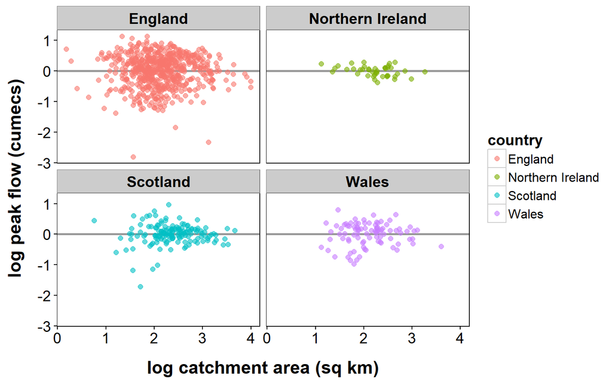

```r
# add residuals to new object
countries.resid <- p_data %>%
  add_residuals(catchment_area_country.mod, var = "resid_ca_c")

# Quick peak at the residuals (don't forget QQ and Leverage Plots..)
countries.resid %>%
  ggplot(aes(x = ca_log, y = resid_ca_c, col = country)) +
  geom_ref_line(h = 0, colour = "gray60", size = 1) +
  geom_point(size = 2, alpha = .6) +
  theme_presi() +
  facet_wrap(~country) +
  labs(x = "log catchment area (sq km)", y = "log peak flow (cumecs)")
```

## 4.2 Q2: Catchment characteristics

**Recall:**

- Which catchment properties affect peak flows and which set of characteristics make up the most representative models?

Understanding peak flows is crucial from a management perspective (e.g. risk, resources). Additonal insight may be gleaned by applying “region” specific models individually. To this end, we apply a series of models to a nested data frame (by country).

Chosen catchment characteristics:

- **DPSBAR**: Overall catchment steepness (mean Drainage Path Slope)
- **FARL**: Flood Attenuation by Reservoirs and Lakes (< 0.8 strong attenuation)
- **FPEXT**: Floodplain extent
- **PROPWET**: proportion of time catchment soils are wet
- **SPRHOST**: Standard percentage runoff (%), weighted by soil class across catchment

### 4.2.1 Analyses

The next steps outline the definition and application of a series of models on the joined peak flow data set.

**1. Nest data frame:**

```r
# add transformed data for modelling
p_data <- all_stations %>%
  mutate(peak_flow_cumecs_log = log10(peak_flow_cumecs),
         ca_log = log10(catchmentArea)) %>%
  filter(is.finite(peak_flow_cumecs_log),
         is.finite(ca_log))

p_data
```

| id | country | catchmentArea | peak_flow_cumecs | DPSBAR | FARL | FPEXT | SPRHOST | PROPWET | peak_flow_cumecs_log | ca_log |
| --- | --- | --- | --- | --- | --- | --- | --- | --- | --- | --- |
| 2001 | Scotland | 551.4 | 126.667 | 97.0 | 0.858 | 0.0555 | 52.88 | 0.65 | 2.1026635 | 2.741467 |
| 2002 | Scotland | 434.4 | 93.977 | 97.3 | 0.845 | 0.0553 | 54.16 | 0.59 | 1.9730216 | 2.637890 |
| 3002 | Scotland | 241.1 | 182.088 | 218.2 | 0.974 | 0.0377 | 49.93 | 0.81 | 2.2602813 | 2.382197 |
| 3003 | Scotland | 330.7 | 447.404 | 148.2 | 0.915 | 0.0488 | 53.57 | 0.81 | 2.6506999 | 2.519434 |
| 4003 | Scotland | 201.0 | 97.393 | 147.7 | 0.908 | 0.0374 | 48.11 | 0.63 | 1.9885277 | 2.303196 |
| 4005 | Scotland | 120.5 | 93.967 | 289.0 | 0.918 | 0.0366 | 52.86 | 0.76 | 1.9729754 | 2.080987 |
| 4006 | Scotland | 116.1 | 92.550 | 164.6 | 0.814 | 0.0479 | 52.93 | 0.83 | 1.9663764 | 2.064832 |
| 6008 | Scotland | 105.9 | 70.412 | 118.3 | 0.839 | 0.0467 | 43.43 | 0.70 | 1.8476467 | 2.024896 |
| 7001 | Scotland | 415.6 | 347.351 | 138.9 | 0.982 | 0.0392 | 55.84 | 0.68 | 2.5407686 | 2.618676 |
| 7002 | Scotland | 781.9 | 900.000 | 117.2 | 0.973 | 0.0483 | 51.62 | 0.56 | 2.9542425 | 2.893151 |

[output cut: 70 more lines]

```r
# nest joined peak flow data set
uk_nested <- p_data %>%
  tidyr::nest(-country)

uk_nested %>% as.data.frame
```

| country | data |
| --- | --- |
| Scotland |  |
| England |  |
| Wales |  |
| Northern Ireland |  |

**2. Define models:**

```r
models <- list(
  mod00_null_intercept = function(x){lm(peak_flow_cumecs_log ~ 1, data = x)},

  mod01_ca = function(x){lm(peak_flow_cumecs_log ~ ca_log, data = x)},

  mod02_ca_farl = function(x){lm(peak_flow_cumecs_log ~
                                   ca_log + FARL, data = x)},
  mod03_ca_sprhost = function(x){lm(peak_flow_cumecs_log ~
                                      ca_log + SPRHOST, data = x)},
  mod04_ca_fpext = function(x){lm(peak_flow_cumecs_log ~
                                    ca_log + FPEXT, data = x)},
  mod04_ca_propwet = function(x){lm(peak_flow_cumecs_log ~
                                      ca_log + PROPWET, data = x)},
  mod05_ca_farl_fpext = function(x){lm(peak_flow_cumecs_log ~
                                         ca_log + FARL + FPEXT, data = x)},
  mod06_ca_farl_propwet = function(x){lm(peak_flow_cumecs_log ~
                                           ca_log + FARL + PROPWET, data = x)},
  mod07_ca_farl_propwet_fpext = function(x){lm(peak_flow_cumecs_log ~
                                                 ca_log + FARL + PROPWET + FPEXT, data = x)},

  mod08_ca_farl_fpext_sprhost_propwet = function(x){lm(peak_flow_cumecs_log ~
                                                         ca_log + FARL + FPEXT + SPRHOST + PROPWET, data = x)}

)
```

**3. Custom function to apply models on nested data frame**:

```r
apply_model <- function(.model, nested_df){

  # takes data column from nested df and "loops"/maps over it
  # to apply models then
  # adds a model column to the nested data frame
  nested_df$model <- map(nested_df$data, possibly(.model, otherwise = NULL))


  # returns nested data frame
  return(nested_df)
}
```

**4. Apply models using custom function:**

```r
uk_nest <- models %>%

  # use custom function and add id column
  map_df(apply_model, uk_nested, .id = "id_model") %>%

  # carry over pertinent columns
  select(id_model, country, model) %>%

  # add model coefficients and performance metrics to data frame.
  mutate(coefficients = map(model, tidy),
         performance = map(model, glance)) %>%
  select(-model)

uk_nest %>% head(20)
```

| id_model | country | coefficients | performance |
| --- | --- | --- | --- |
| mod00_null_intercept | Scotland |  |  |
| mod00_null_intercept | England |  |  |
| mod00_null_intercept | Wales |  |  |
| mod00_null_intercept | Northern Ireland |  |  |
| mod01_ca | Scotland |  |  |
| mod01_ca | England |  |  |
| mod01_ca | Wales |  |  |
| mod01_ca | Northern Ireland |  |  |
| mod02_ca_farl | Scotland |  |  |
| mod02_ca_farl | England |  |  |

[output cut: 10 more lines]

**5. Model assessment - coefficients:**

```r
# unnest data frame, dropping other nested column
uk_coefficients <- uk_nest %>%
  unnest(coefficients, .drop = T)

# add columns with factors for plotting/classification
# re-order factors for plotting with fct_relevel
uk_coefficients <- uk_coefficients %>%
  mutate(estimate_factor = ifelse(p.value < 0.05,
                                  ifelse(estimate > 0,
                                         "positive",
                                         "negative"),
                                  "not sign.") %>%
           fct_relevel("positive", "negative"),
         id_model = fct_relevel(as.factor(id_model), "mod00_null_intercept"),
         id_model_num = id_model %>% as.numeric())



uk_coefficients %>% as.data.frame() %>% head(20)
```

|  | id_model | country | term | estimate | std.error | statistic | p.value | estimate_factor | id_model_num |
| --- | --- | --- | --- | --- | --- | --- | --- | --- | --- |
| 1 | mod00_null_intercept | Scotland | (Intercept) | 1.9739807 | 0.05031525 | 39.2322526 | 9.070960e-80 | positive | 1 |
| 2 | mod00_null_intercept | England | (Intercept) | 1.3660362 | 0.03059852 | 44.6438595 | 2.140609e-195 | positive | 1 |
| 3 | mod00_null_intercept | Wales | (Intercept) | 1.8108276 | 0.06480897 | 27.9410006 | 3.922848e-46 | positive | 1 |
| 4 | mod00_null_intercept | Northern Ireland | (Intercept) | 1.7378453 | 0.06334168 | 27.4360474 | 5.279224e-28 | positive | 1 |
| 5 | mod01_ca | Scotland | (Intercept) | -0.4287432 | 0.13501321 | -3.1755649 | 1.824668e-03 | negative | 2 |
| 6 | mod01_ca | Scotland | ca_log | 1.0112985 | 0.05559688 | 18.1898423 | 2.353098e-39 | positive | 2 |
| 7 | mod01_ca | England | (Intercept) | -0.7079294 | 0.08213922 | -8.6186527 | 5.704855e-17 | negative | 2 |
| 8 | mod01_ca | England | ca_log | 0.9772540 | 0.03740628 | 26.1253990 | 7.816029e-102 | positive | 2 |
| 9 | mod01_ca | Wales | (Intercept) | -0.3544807 | 0.17213049 | -2.0593718 | 4.238043e-02 | negative | 2 |
| 10 | mod01_ca | Wales | ca_log | 1.0295205 | 0.07977233 | 12.9057340 | 4.276103e-22 | positive | 2 |

[output cut: 10 more lines]

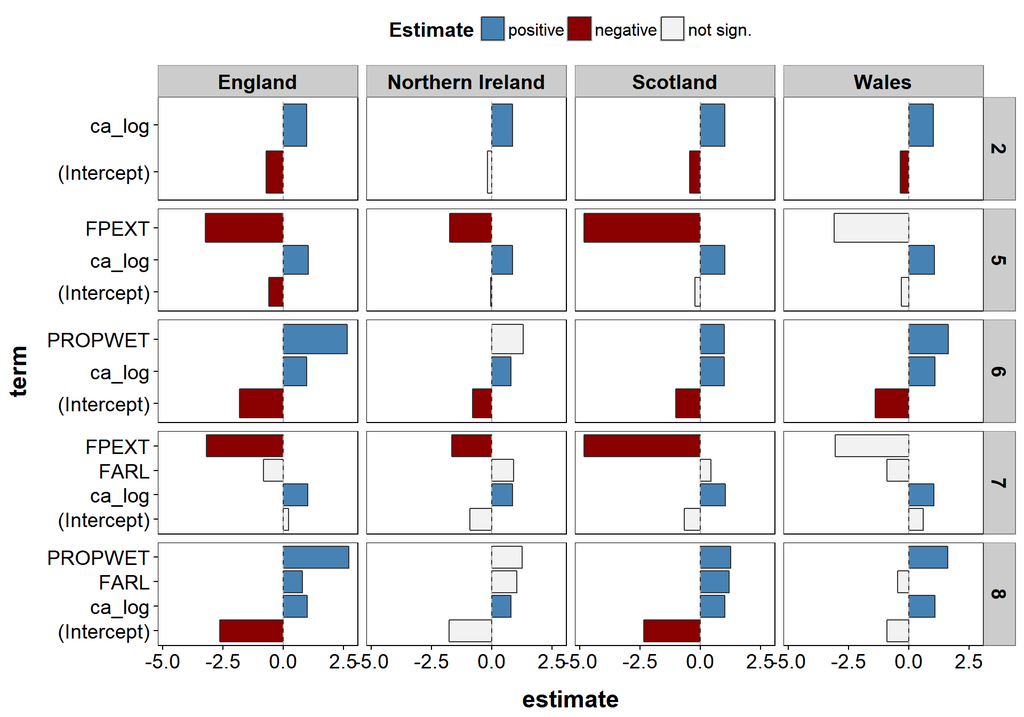

```r
coef.plot <- uk_coefficients %>%

  # select subset of models for plotting/discussion
  filter(id_model_num %in% c(2,5,6,7,8)) %>%

  ggplot(aes(y = estimate,
             x = term, fill = estimate_factor)) +

  geom_bar(stat = "identity", position = "dodge",col = "gray20") +
  coord_flip() +
  facet_grid(id_model_num~country, scales = "free_y") +

  geom_hline(yintercept = 0, linetype = 2, col = "darkgrey") +

  theme_presi() +
  theme(panel.grid.major.x = element_blank(),
        panel.grid.minor.x = element_blank(),
        legend.position = "top",
        axis.text.x = element_text(angle = 0)) +
  scale_fill_manual(name = "Estimate", values = c("negative" = "darkred",
                                                  "positive" = "steelblue",
                                                  "not sign." = "grey95"))

coef.plot
```

### 4.2.2 Results (Part I)

- Differences in effect size between countries (e.g. floodplain extent, proportion wet).
- Floodplain extent and proportion of wet catchment area largest effects.
- *Note:* A full analyses would require a look at residuals, QQ-plots, and leverages.

**6. Model assessment - relative and absolute fit:**

```r
uk_performance <- uk_nest %>%
  tidyr::unnest(performance, .drop = T)

uk_performance <- uk_performance %>%
  filter(id_model != "mod00_null_intercept") %>%
  group_by(country) %>%
  arrange(AIC, .by_group = T) %>%
  rename(AIC_val = AIC) %>%
  mutate(dAIC = AIC_val - min(AIC_val),
         minAIC = ifelse(dAIC < 10 ,"keep", "less support"))


uk_performance %>% as.data.frame() %>% head(20)
```

|  | id_model | country | r.squared | adj.r.squared | sigma | statistic | p.value | df | logLik | AIC_val | BIC | deviance | df.residual | dAIC | minAIC |
| --- | --- | --- | --- | --- | --- | --- | --- | --- | --- | --- | --- | --- | --- | --- | --- |
| 1 | mod08_ca_farl_fpext_sprhost_propwet | England | 0.7653624 | 0.7634455 | 0.3699647 | 399.25563 | 5.966149e-190 | 6 | -259.38256 | 532.76511 | 563.75053 | 83.7668326 | 612 | 0.000000 | keep |
| 2 | mod07_ca_farl_propwet_fpext | England | 0.7179774 | 0.7161371 | 0.4052742 | 390.14621 | 7.186522e-167 | 5 | -316.22160 | 644.44320 | 671.00213 | 100.6835337 | 613 | 111.678091 | less support |
| 3 | mod06_ca_farl_propwet | England | 0.7165271 | 0.7151421 | 0.4059839 | 517.33069 | 1.397920e-167 | 4 | -317.80656 | 645.61312 | 667.74556 | 101.2012976 | 614 | 112.848006 | less support |
| 4 | mod04_ca_propwet | England | 0.7145621 | 0.7136339 | 0.4070573 | 769.79218 | 3.713822e-168 | 3 | -319.94113 | 647.88226 | 665.58821 | 101.9028160 | 615 | 115.117147 | less support |
| 5 | mod03_ca_sprhost | England | 0.6693480 | 0.6682727 | 0.4381121 | 622.48083 | 1.609238e-148 | 3 | -365.37709 | 738.75419 | 756.46014 | 118.0444831 | 615 | 205.989075 | less support |
| 6 | mod05_ca_farl_fpext | England | 0.5713340 | 0.5692396 | 0.4992437 | 272.78358 | 1.722102e-112 | 4 | -445.59707 | 901.19414 | 923.32658 | 153.0359867 | 614 | 368.429026 | less support |
| 7 | mod04_ca_fpext | England | 0.5692239 | 0.5678230 | 0.5000639 | 406.32789 | 3.406978e-113 | 3 | -447.11442 | 902.22884 | 919.93479 | 153.7893211 | 615 | 369.463727 | less support |
| 8 | mod02_ca_farl | England | 0.5291082 | 0.5275769 | 0.5228297 | 345.51631 | 2.649938e-101 | 3 | -474.62771 | 957.25542 | 974.96137 | 168.1108190 | 615 | 424.490310 | less support |
| 9 | mod01_ca | England | 0.5256198 | 0.5248497 | 0.5243366 | 682.53647 | 7.816029e-102 | 2 | -476.90840 | 959.81679 | 973.09626 | 169.3562124 | 616 | 427.051684 | less support |
| 10 | mod08_ca_farl_fpext_sprhost_propwet | Northern Ireland | 0.8953826 | 0.8808524 | 0.1416958 | 61.62220 | 1.224058e-16 | 6 | 25.71281 | -37.42562 | -25.26194 | 0.7227968 | 36 | 0.000000 | keep |

[output cut: 10 more lines]

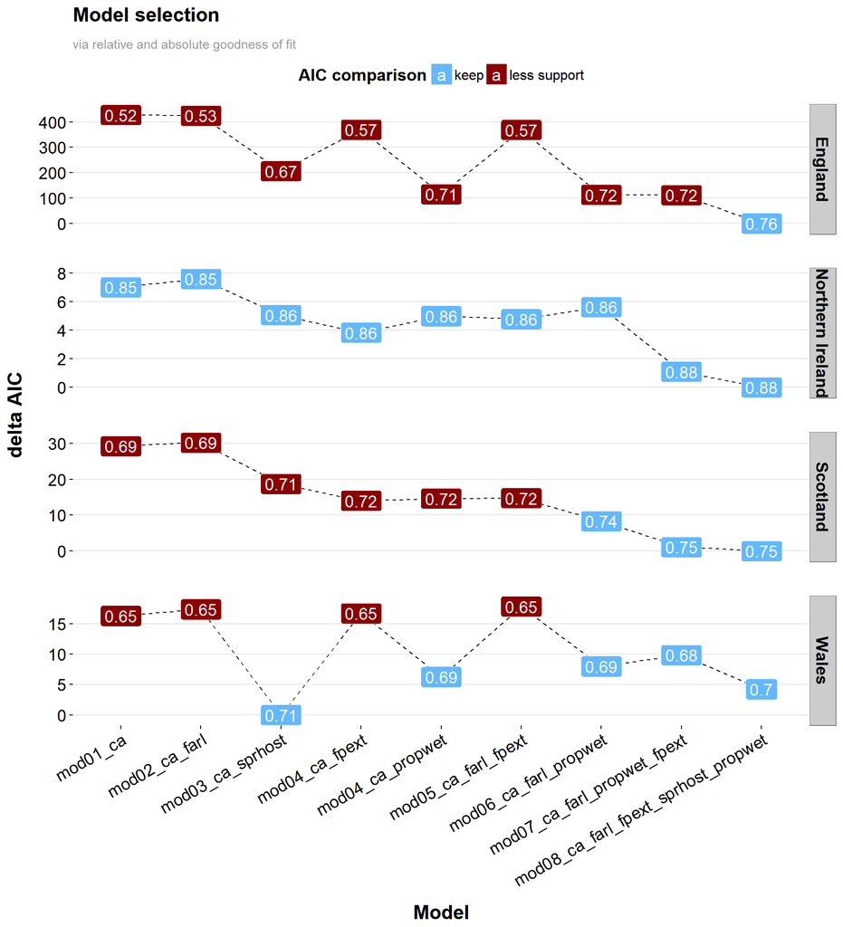

```r
# custom function based on gglplot2, code available in raw *.rmd document
aic_plot()
```

### 4.2.3 Results (Part II)

- Lowest $\Delta AIC$ associated with high(est) $R^2$ (likely from over-fitting at small sample sizes, remaining co-linearity, etc.)
- Potentially resolved by using criterion that penalizes more for larger number of included covariates (e.g. $AIC_c$, $BIC$, etc.)
- Continue anylseswith models selected based on agreement with assumptions (QQ-plots, etc.), predictive power ($R^2$), likelihood as well as information content ($\Delta AIC$ or others) and use averages of best model set.

# 5 Conclusion

- Identified peak flow differences between countries and catchment characteristics that may drive peak flow magnitude

Developed analyses work flow that:

- can be applied for different settings/fields
- is scalable and adaptable
- aids in communicating results
- Using the `tidyverse` is not a bad idea at all!